# Análisis de causas de la obesidad

Miranda Leiva Lázaro

2024-12-24

## Análisis exploratorio de datos y limpieza

El conjunto de datos seleccionado recoge datos sobre hábitos y características físicas de 2111 individos de Colombia, Perú y México.

Instalo las librerías necesarias.

```r
if (!require(ggplot2)) {
  install.packages("ggplot2")
}
if (!require(dplyr)) {
  install.packages("dplyr")
}
if (!require(maps)) {
  install.packages("maps")
}
if (!require(corrr)) {
  install.packages("corrr")
}
if (!require(ggcorrplot)) {
  install.packages("ggcorrplot")
}
if (!require(FactoMineR)) {
  install.packages("FactoMineR")
}
if (!require(factoextra)) {
  install.packages("factoextra")
}
if (!require(corrr)) {
  install.packages("corrr")
}
if (!require(mltools)) {
  install.packages("mltools")
}
if (!require(data.table)) {
  install.packages("data.table")
}
```

Importo el conjunto de datos.

```r
df <- read.csv("../data/ObesityDataSet.csv")
```

Compruebo si hay valores faltantes en alguna de las columnas.

```r
colSums(is.na(df))
```

```
##                         Gender                            Age
##                              0                              0
##                         Height                         Weight
##                              0                              0
## family_history_with_overweight                           FAVC
##                              0                              0
##                           FCVC                            NCP
##                              0                              0
##                           CAEC                          SMOKE
##                              0                              0
##                           CH2O                            SCC
##                              0                              0
##                            FAF                            TUE
##                              0                              0
##                           CALC                         MTRANS
##                              0                              0
##                     NObeyesdad
##                              0
```

Imprimo el conjunto de datos para ver los nombres de las columnas, sus tipos y la estructura de su contenido.

```r
head(df)
```

```
##   Gender Age Height Weight family_history_with_overweight FAVC FCVC NCP
## 1 Female  21   1.62   64.0                            yes   no    2   3
## 2 Female  21   1.52   56.0                            yes   no    3   3
## 3   Male  23   1.80   77.0                            yes   no    2   3
## 4   Male  27   1.80   87.0                             no   no    3   3
## 5   Male  22   1.78   89.8                             no   no    2   1
## 6   Male  29   1.62   53.0                             no  yes    2   3
##        CAEC SMOKE CH2O SCC FAF TUE       CALC                MTRANS
## 1 Sometimes    no    2  no   0   1         no Public_Transportation
## 2 Sometimes   yes    3 yes   3   0  Sometimes Public_Transportation
## 3 Sometimes    no    2  no   2   1 Frequently Public_Transportation
## 4 Sometimes    no    2  no   2   0 Frequently               Walking
## 5 Sometimes    no    2  no   0   0  Sometimes Public_Transportation
## 6 Sometimes    no    2  no   0   0  Sometimes            Automobile
##            NObeyesdad
## 1       Normal_Weight
## 2       Normal_Weight
## 3       Normal_Weight
## 4  Overweight_Level_I
## 5 Overweight_Level_II
## 6       Normal_Weight
```

Algunas columnas contienen decimales que no aportan nada. Cambio el tipo de datos de esas columnas.

```r
df$Age <- as.integer(df$Age)
df$Height <- round(df$Height, 2)
df$Weight <- as.integer(df$Weight)
df$FCVC <- as.integer(df$FCVC)
df$NCP <- as.integer(df$NCP)
df$CH2O <- as.integer(df$CH2O)
df$FAF <- as.integer(df$FAF)
df$TUE <- as.integer(df$TUE)

head(df)
```

```
##   Gender Age Height Weight family_history_with_overweight FAVC FCVC NCP
## 1 Female  21   1.62     64                            yes   no    2   3
## 2 Female  21   1.52     56                            yes   no    3   3
## 3   Male  23   1.80     77                            yes   no    2   3
## 4   Male  27   1.80     87                             no   no    3   3
## 5   Male  22   1.78     89                             no   no    2   1
## 6   Male  29   1.62     53                             no  yes    2   3
##        CAEC SMOKE CH2O SCC FAF TUE       CALC                MTRANS
## 1 Sometimes    no    2  no   0   1         no Public_Transportation
## 2 Sometimes   yes    3 yes   3   0  Sometimes Public_Transportation
## 3 Sometimes    no    2  no   2   1 Frequently Public_Transportation
## 4 Sometimes    no    2  no   2   0 Frequently               Walking
## 5 Sometimes    no    2  no   0   0  Sometimes Public_Transportation
## 6 Sometimes    no    2  no   0   0  Sometimes            Automobile
##            NObeyesdad
## 1       Normal_Weight
## 2       Normal_Weight
## 3       Normal_Weight
## 4  Overweight_Level_I
## 5 Overweight_Level_II
## 6       Normal_Weight
```

## Planteamiento de preguntas

El conjunto de datos presenta información como hábitos o características físicas de personas, incluyendo su peso y el nivel de peso al que corresponde (insuficiente. normal, sobrepeso nivel 1, sobrepeso nivel 2, obesidad nivel 1, obesidad nivel 2, obesidad nivel 3). Teniendo todo esto, puedo analizar cómo influye cada uno de los datos sobre las personas en su composición corporal, con el objetivo de que el público general pueda tomar acciones sobre aquellas condiciones y hábitos de vida sobre los que tenga capacidad de cambio y decisión.

Igual de relevante que encontrar los factores más relacionados con la composición corporal, lo es encontrar los que influyen de manera mínima, para descartar mitos. El exceso de información sobre métodos de adelgazamiento ha dado lugar a relatos sin respaldo científico, que pueden ser confrontados mostrando el poco o nulo peso que tienen.

## Matriz de correlación y selección de variables

Dado que el conjunto de datos contiene muchas variables, voy a dibujar una matriz de correlación que analizaré para encontrar las que más influyen sobre la categoría de peso de los individuos.

Comienzo creando una copia del conjunto de datos que albergará las variables factorizadas.

```r
df_2 <- df
```

Para poder normalizar los datos, factorizo las categorías de peso, dando un número mayor cuanto mayor es el peso. Guardo el resultado en una nueva columna y elimino la original. La columna resultado, “Weight_level”, será la variable objetivo de este análisis.

```r
df_2$TARGET_Weight_level <- factor(df_2$NObeyesdad, levels = c(
  "Insufficient_Weight", "Normal_Weight", "Overweight_Level_I",
  "Overweight_Level_II", "Obesity_Type_I", "Obesity_Type_II",
  "Obesity_Type_III"), labels = 0:6
)

df_2$NObeyesdad <- NULL
```

Algunas variables categóricas pueden transformarse en factores directamente. Las transformo dejando sus nombres originales.

```r
df_2$family_history_with_overweight <- factor(df_2$family_history_with_overweight,
  levels = c("no", "yes"), labels = 0, 1)

df_2$FAVC <- factor(df_2$FAVC, levels = c("no", "yes"), labels = 0, 1)

df_2$CAEC <- factor(df_2$CAEC, levels = c("no", "Sometimes", "Frequently",
  "Always"), labels = 0:3)

df_2$SMOKE <- factor(df_2$SMOKE, levels = c("no", "yes"), labels = 0, 1)

df_2$SCC <- factor(df_2$SCC, levels = c("no", "yes"), labels = 0, 1)

df_2$CALC <- factor(df_2$CALC, levels = c("no", "Sometimes", "Frequently",
  "Always"), labels = 0:3)
```

Aplico el método del one-hot encoding (codificación en caliente) creando variables de tipo “dummy” a partir de la variable categórica que incluye el medio de transporte (“MTRANS”), y la que incluye el género (“Gender”).

```r
library(dplyr)

dummy_vars <- model.matrix(~ Gender + MTRANS - 1, data = df_2) %>%
  as.data.frame()

df_2 <- df_2 %>%
  select(-Gender, -MTRANS) %>%
  bind_cols(dummy_vars)

head(df_2)
```

```
##   Age Height Weight family_history_with_overweight FAVC FCVC NCP CAEC SMOKE
## 1  21   1.62     64                             02   01    2   3    1    01
## 2  21   1.52     56                             02   01    3   3    1    02
## 3  23   1.80     77                             02   01    2   3    1    01
## 4  27   1.80     87                             01   01    3   3    1    01
## 5  22   1.78     89                             01   01    2   1    1    01
## 6  29   1.62     53                             01   02    2   3    1    01
##   CH2O SCC FAF TUE CALC TARGET_Weight_level GenderFemale GenderMale MTRANSBike
## 1    2  01   0   1    0                   1            1          0          0
## 2    3  02   3   0    1                   1            1          0          0
## 3    2  01   2   1    2                   1            0          1          0
## 4    2  01   2   0    2                   2            0          1          0
## 5    2  01   0   0    1                   3            0          1          0
## 6    2  01   0   0    1                   1            0          1          0
##   MTRANSMotorbike MTRANSPublic_Transportation MTRANSWalking
## 1               0                           1             0
## 2               0                           1             0
## 3               0                           1             0
## 4               0                           0             1
## 5               0                           1             0
## 6               0                           0             0
```

Convierto todas las columnas de tipo factor a numéricas para poder normalizarlas.

```r
df_2 <- df_2 %>%
  mutate(across(where(is.factor), as.integer))

head(df_2)
```

```
##   Age Height Weight family_history_with_overweight FAVC FCVC NCP CAEC SMOKE
## 1  21   1.62     64                              2    1    2   3    2     1
## 2  21   1.52     56                              2    1    3   3    2     2
## 3  23   1.80     77                              2    1    2   3    2     1
## 4  27   1.80     87                              1    1    3   3    2     1
## 5  22   1.78     89                              1    1    2   1    2     1
## 6  29   1.62     53                              1    2    2   3    2     1
##   CH2O SCC FAF TUE CALC TARGET_Weight_level GenderFemale GenderMale MTRANSBike
## 1    2   1   0   1    1                   2            1          0          0
## 2    3   2   3   0    2                   2            1          0          0
## 3    2   1   2   1    3                   2            0          1          0
## 4    2   1   2   0    3                   3            0          1          0
## 5    2   1   0   0    2                   4            0          1          0
## 6    2   1   0   0    2                   2            0          1          0
##   MTRANSMotorbike MTRANSPublic_Transportation MTRANSWalking
## 1               0                           1             0
## 2               0                           1             0
## 3               0                           1             0
## 4               0                           0             1
## 5               0                           1             0
## 6               0                           0             0
```

Normalizo las columnas para que todas tengan el mismo peso en la variable objetivo.

```r
#df_norm <- df_2 %>%
  #mutate(across(where(is.numeric), scale))


df_norm <- as.data.frame(scale(df_2))

head(df_norm)
```

```
##          Age     Height      Weight family_history_with_overweight       FAVC
## 1 -0.4711813 -0.8741725 -0.85241355                      0.4721794 -2.7591155
## 2 -0.4711813 -1.9451986 -1.15910663                      0.4721794 -2.7591155
## 3 -0.1541570  1.0536746 -0.35403729                      0.4721794 -2.7591155
## 4  0.4798916  1.0536746  0.02932907                     -2.1168357 -2.7591155
## 5 -0.3126692  0.8394694  0.10600234                     -2.1168357 -2.7591155
## 6  0.7969159 -0.8741725 -1.27411654                     -2.1168357  0.3622633
##         FCVC        NCP       CAEC      SMOKE      CH2O        SCC        FAF
## 1 -0.3556393  0.5739589 -0.3002744 -0.1458657 0.4802286 -0.2182203 -0.8822194
## 2  1.3127041  0.5739589 -0.3002744  6.8523733 2.1503482  4.5803537  2.7200344
## 3 -0.3556393  0.5739589 -0.3002744 -0.1458657 0.4802286 -0.2182203  1.5192831
## 4  1.3127041  0.5739589 -0.3002744 -0.1458657 0.4802286 -0.2182203  1.5192831
## 5 -0.3556393 -1.8348427 -0.3002744 -0.1458657 0.4802286 -0.2182203 -0.8822194
## 6 -0.3556393  0.5739589 -0.3002744 -0.1458657 0.4802286 -0.2182203 -0.8822194
##          TUE       CALC TARGET_Weight_level GenderFemale GenderMale  MTRANSBike
## 1  1.0620188 -1.4188354         -1.06408228    1.0116740 -1.0116740 -0.05766646
## 2 -0.6546134  0.5210361         -1.06408228    1.0116740 -1.0116740 -0.05766646
## 3  1.0620188  2.4609075         -1.06408228   -0.9879925  0.9879925 -0.05766646
## 4 -0.6546134  2.4609075         -0.56031962   -0.9879925  0.9879925 -0.05766646
## 5 -0.6546134  0.5210361         -0.05655696   -0.9879925  0.9879925 -0.05766646
## 6 -0.6546134  0.5210361         -1.06408228   -0.9879925  0.9879925 -0.05766646
##   MTRANSMotorbike MTRANSPublic_Transportation MTRANSWalking
## 1     -0.07235754                   0.5795833    -0.1650385
## 2     -0.07235754                   0.5795833    -0.1650385
## 3     -0.07235754                   0.5795833    -0.1650385
## 4     -0.07235754                  -1.7245603     6.0563227
## 5     -0.07235754                   0.5795833    -0.1650385
## 6     -0.07235754                  -1.7245603    -0.1650385
```

Muevo la variable objetivo a la última posición para diferenciarla más fácilmente.

```r
df_norm <- df_norm %>%
  select(-TARGET_Weight_level, everything(), TARGET_Weight_level)
```

Dibujo una matriz de correlación para encontrar las variables que más influyen en la variable objetivo “Weight_level”.

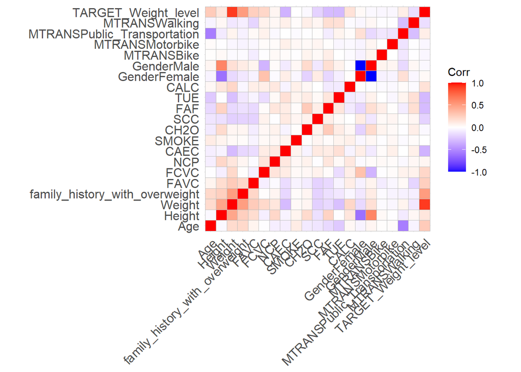

```r
library("ggcorrplot")

corr_matrix <- cor(df_norm %>% select(where(is.numeric)))
ggcorrplot(corr_matrix)
```

Aunque ya puedo empezar a apreciar el resultado, hay demasiadas variables a analizar. Voy a ordenarlas por correlación en valor absoluto con la variable objetivo “TARGET_Weight_level” para seleccionar las más relevantes.

```r
corr_matrix_target <- corr_matrix[, "TARGET_Weight_level"]
corr_matrix_target_sorted <- sort(abs(corr_matrix_target), decreasing = TRUE)

print(corr_matrix_target_sorted)
```

```
##            TARGET_Weight_level                         Weight
##                    1.000000000                    0.912571940
## family_history_with_overweight                           CAEC
##                    0.505148418                    0.329349716
##                            TUE                            FAF
##                    0.298112433                    0.286143171
##                            Age                           FAVC
##                    0.269966251                    0.247793200
##                           FCVC                            SCC
##                    0.212095470                    0.194507656
##                           CALC                  MTRANSWalking
##                    0.151752322                    0.138563989
##                         Height    MTRANSPublic_Transportation
##                    0.132625393                    0.085605992
##                            NCP                MTRANSMotorbike
##                    0.050017354                    0.037247265
##                     MTRANSBike                     GenderMale
##                    0.036478957                    0.031463618
##                   GenderFemale                           CH2O
##                    0.031463618                    0.029049362
##                          SMOKE
##                    0.003442179
```

La primera variable es la propia variable objetivo, y la segunda es el peso (a partir del cual se construye la variable objetivo de nivel de peso), por tanto las ignoro. Las siguientes en importancia son los antecedentes familiares de sobrepeso (0.5), el consumo de alimentos entre comidas principales o CAEC (0.33), el tiempo de uso de aparatos tecnológicos o TUE (0.30), la frecuencia de actividad física o FAF (0.29), la edad (0.27) y el consumo de comida hipercalórica o FAVC (0.25). El resto de variables aportan menos peso (aproximadamente 0.2 como mucho), así que no me parecen ya relevantes para buscar patrones.

Compruebo si las variables seleccionadas como las más relevantes contribuyen de forma positiva (aumento de peso) o negativa (disminución de peso) sobre la variable objetivo.

```r
corr_matrix_target[c("family_history_with_overweight", "CAEC", "TUE", "FAF", "Age", "FAVC")]
```

```
## family_history_with_overweight                           CAEC
##                      0.5051484                     -0.3293497
##                            TUE                            FAF
##                     -0.2981124                     -0.2861432
##                            Age                           FAVC
##                      0.2699663                      0.2477932
```

Del resultado se concluye que las siguientes características están asociadas en el siguiente orden de relevancia con un mayor nivel de peso en los individuos: Tener antecedentes familiares de sobrepeso, ser más mayor y consumir alimentos hipercalóricos. Por el contrario, parece influir en un menor peso: consumir alimentos entre comidas principales más a menudo, usar aparatos tecnológicos durante más tiempo y realizar actividad física más a menudo.

## Gráficos estadísticos

Voy a crear visualizaciones para representar de forma clara y atractiva las conclusiones del análisis que he realizado en el apartado anterior.

El siguiente gráfico de barras permite apreciar la diferencia en la influencia sobre el nivel de peso entre las correlaciones más importantes, y las menos. De esta forma, se demuestra que algunas características son irrelevantes, mientras otras influyen en gran medida.

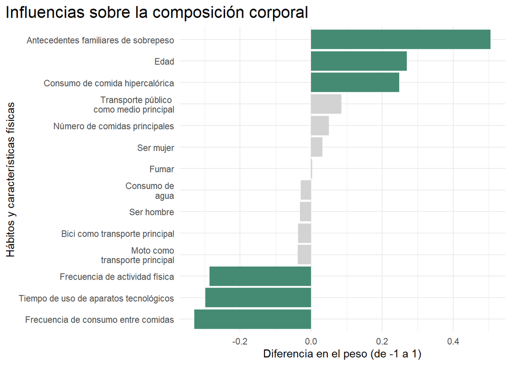

```r
df_3 <- data.frame(
  Variable=c(
    "family_history_with_overweight", "CAEC", "TUE", "FAF", "Age", "FAVC",
    "SMOKE", "CH2O", "GenderFemale", "GenderMale", "MTRANSBike",
    "MTRANSMotorbike", "NCP", "MTRANSPublic_Transportation"
  ),
  Correlation = corr_matrix_target[c(
    "family_history_with_overweight", "CAEC", "TUE", "FAF", "Age", "FAVC",
    "SMOKE", "CH2O", "GenderFemale", "GenderMale", "MTRANSBike",
    "MTRANSMotorbike", "NCP", "MTRANSPublic_Transportation"
  )],
  Group=c(
    rep("Muy influyente", 6),
    rep("Irrelevante", 8)
  )
)

df_3$VariableLabel <- c(
  "Antecedentes familiares de sobrepeso", "Frecuencia de consumo entre comidas",
  "Tiempo de uso de aparatos tecnológicos", "Frecuencia de actividad física",
  "Edad", "Consumo de comida hipercalórica", "Fumar", "Consumo de
  agua", "Ser mujer", "Ser hombre", "Bici como transporte principal", "Moto como
  transporte principal", "Número de comidas principales", "Transporte público
  como medio principal"
)

ggplot(df_3, aes(x=reorder(VariableLabel, Correlation), y=Correlation,
  fill=Group)) + geom_bar(stat="identity") + coord_flip() + labs(
    title = "Influencias sobre la composición corporal",
    x="Hábitos y características físicas",
    y="Diferencia en el peso (de -1 a 1)"
  ) + scale_fill_manual(values=c("Muy influyente"="#458B74", "Irrelevante"=
  "lightgray"), guide="none") + theme_minimal() + theme(plot.title=element_text
  (size=16), plot.title.position="plot")
```

Un dato muy revelador es que a mayor frecuencia de consumo entre comidas, y a mayor uso de tecnología, menor será el nivel de peso. Yo relaciono esto con la frecuencia de actividad física y la edad, e intuyo que esto sucede porque los individuos jóvenes suelen usar más los aparatos tecnológicos, y estos son los que menos tienden a tener un nivel de peso alto; además, los deportistas suelen consumir alimentos entre comidas principales, así que esto tambíén podría estar influyendo.

La variable que más importancia ha resultado tener son los antecedentes familiares. Al ser binaria, puedo visualizar su relación con el nivel de peso mediante un diagrama de caja. Recordemos los niveles de peso: 1. Insuficiente 2. Normal 3. Sobrepeso nivel 1 4. Sobrepeso nivel 2 5. Obesidad nivel 1 6. Obesidad nivel 2 7. Obesidad nivel 3

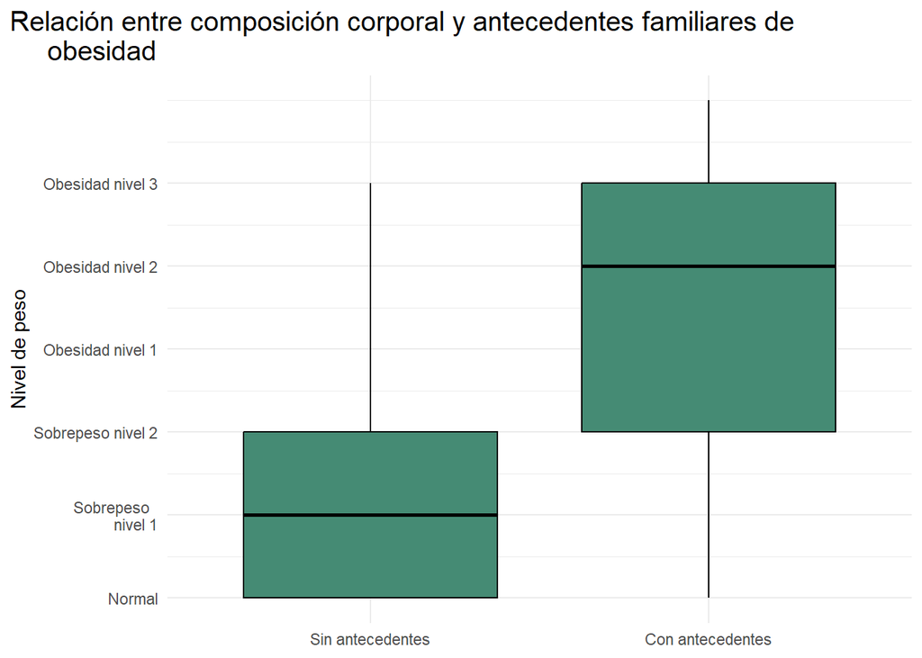

```r
ggplot(df_2, aes(x=as.factor(family_history_with_overweight),
  y=TARGET_Weight_level)) +
  geom_boxplot(fill="#458B74", color="black") +
  labs(
    title="Relación entre composición corporal y antecedentes familiares de
     obesidad",
    y="Nivel de peso"
  ) +
  scale_x_discrete(labels=c("1"="Sin antecedentes", "2"="Con antecedentes")
  ) +
  scale_y_continuous(breaks=0:6, labels=c("Insuficiente", "Normal", "Sobrepeso
  nivel 1", "Sobrepeso nivel 2", "Obesidad nivel 1", "Obesidad nivel 2",
  "Obesidad nivel 3"), limits=c(1, 7)) + theme_minimal() +theme(axis.title.x=
  element_blank(), plot.title=element_text(size=15), plot.title.position="plot")
```

La segunda variable en importancia es la frecuencia de consumo de alimentos entre comidas principales, y al ser categórica se puede mostrar también mediante un diagrama de caja.

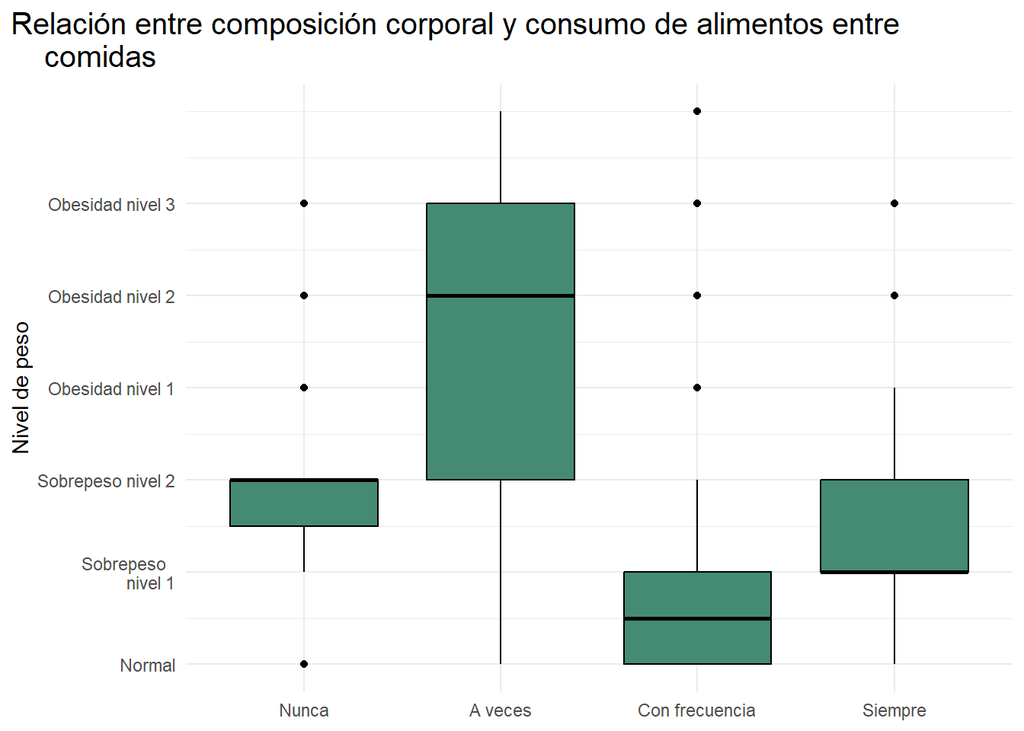

```r
ggplot(df_2, aes(x=as.factor(CAEC),
  y=TARGET_Weight_level)) +
  geom_boxplot(fill="#458B74", color="black") +
  labs(
    title="Relación entre composición corporal y consumo de alimentos entre
    comidas", y="Nivel de peso"
  ) +
  scale_x_discrete(labels=c("1"="Nunca", "2"="A veces",
  "3"="Con frecuencia", "4"="Siempre")
  ) +
  scale_y_continuous(breaks=0:6, labels=c("Insuficiente", "Normal", "Sobrepeso
  nivel 1", "Sobrepeso nivel 2", "Obesidad nivel 1", "Obesidad nivel 2",
  "Obesidad nivel 3"), limits=c(1, 7)) + theme_minimal() +theme(axis.title.x=
  element_blank(), plot.title=element_text(size=15), plot.title.position="plot")
```

Otras variables han demostrado tener influencia sobre el nivel de peso, pero no se han incluido en este análisis porque el foco era contestar a las preguntas: cuáles son las variables más influyentes sobre el nivel de peso y de qué forma influyen, y qué variables influyen muy levemente o en absoluto y por tanto no deberían ser el foco de atención en estrategias de adelgazamiento.

Los resultados del análisis demuestran la preocupante prevalencia del sobrepeso y la obesidad en los países estudiados (Colombia, Perú y México). Aunque no lo abordaré en este análisis, sería interesante comprobar si estos valores tan elevados se dan también en otros países.

## Fuentes

- Obesity based on eating habits & physical cond. (2025). Disponible en: https://www.kaggle.com/datasets/ankurbajaj9/obesity-levels/data
- Pandas DataFrame (2025). Disponible en: https://www.geeksforgeeks.org/python-pandas-dataframe/
- factor: Factors (2025). Disponible en: https://www.rdocumentation.org/packages/base/versions/3.6.2/topics/factor
- Tutorial de análisis de componentes principales en R (2025). Disponible en: https://www.datacamp.com/es/tutorial/pca-analysis-r
- One-hot encoding in R: three simple methods (2025). Disponible en: https://datatricks.co.uk/one-hot-encoding-in-r-three-simple-methods
- R - How to one hot encoding a single column while keep other columns still? (2025). Disponible en: https://stackoverflow.com/questions/52539750/r-how-to-one-hot-encoding-a-single-column-while-keep-other-columns-still
- How to R Convert Factor to Numeric in R? (2025). Disponible en: https://sparkbyexamples.com/r-programming/r-convert-factor-to-numeric-in-r/#:~:text=Convert%20Factor%20to%20Numeric%20With,column%20converted%20from%20the%20factor.
- Principal Component Analysis (PCA) in R (2025). Disponible en: https://www.youtube.com/watch?v=jFN4qkSOd4I
- Funcion ggplot() de ggplot2 (2025). Disponible en: https://rpubs.com/daniballari/ggplot
- RCHARTS COLORS (2025). Disponible en: https://r-charts.com/colors/